# Exercise 8

Niclas Simmler

09.04.20

# Exercise 8.1

Have not looked at ARIMA yet.

# Exercise 8.2

There is a study on the development of beluga whales that focusses on the nursing behaviour of mother and calf. During a total of 160 time periods (each lasting 6 hours) subsequent to birth, the following variables were observed for Hudson, a beluga calf. Zoologists use this data to ascertain the health of this young whale. A nursing bout is defined as a successful nursing episode where milk was obtained. We would like to model the nursing time by means of the other variables. Count variables have already undergone a square root transformation to stabilize their va- riance (first-aid-transformation). You will find the data in the file beluga.dat. Load the data in the usual way and create a time series matrix:

```r
d.beluga <- read.table("http://stat.ethz.ch/Teaching/Datasets/WBL/beluga.dat", header = TRUE)
d.beluga <- ts(d.beluga)
```

## a)

Fit the model $NURSING = \beta_0 + \beta_1 PERIOD + \beta_2 BOUTS + \beta_3 LOCKONS + \beta_4 DAYNIGHT$ using ordinary linear regression. Check the independence of the residuals. What conclusions can zoologists draw from this analysis?

```r
olm.fit <- lm(NURSING ~ ., data = d.beluga)
summary(olm.fit)
```

```
Call:
lm(formula = NURSING ~ ., data = d.beluga)

Residuals:
    Min      1Q  Median      3Q     Max
-4.4457 -0.9018 -0.0850  1.0952  3.9548

Coefficients:
              Estimate Std. Error t value Pr(>|t|)
(Intercept)  0.5602842  0.5502170   1.018  0.31012
PERIOD       0.0001998  0.0031937   0.063  0.95020
BOUTS        0.8784967  0.3336237   2.633  0.00932 **
LOCKONS      2.3903512  0.2035042  11.746  < 2e-16 ***
DAYNIGHT    -0.3416237  0.2510156  -1.361  0.17550
---
Signif. codes:  0 ‘***’ 0.001 ‘**’ 0.01 ‘*’ 0.05 ‘.’ 0.1 ‘ ’ 1

Residual standard error: 1.582 on 155 degrees of freedom
Multiple R-squared:  0.842, Adjusted R-squared:  0.8379
F-statistic: 206.5 on 4 and 155 DF,  p-value: < 2.2e-16
```

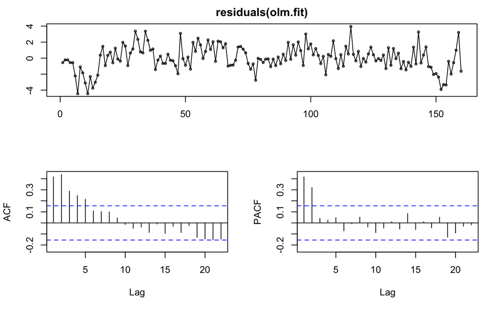

```r
tsdisplay(residuals(olm.fit))
```

There is still a slight trend visible in the residuals. This could indicate that there are some other structures still hidden. This is also supported by the relatively slowly decaying ACF plot. Also the PACF plot shows some dependencies towards other lags. This also means that the output of $lm$ can be highly inaccurate. Zoologists cannot draw any conclusions from the output.

## b)

Due to the correlations involved, an AR(p) model should be assumed for the residuals. Determine the order p of this model, and estimate the parameters

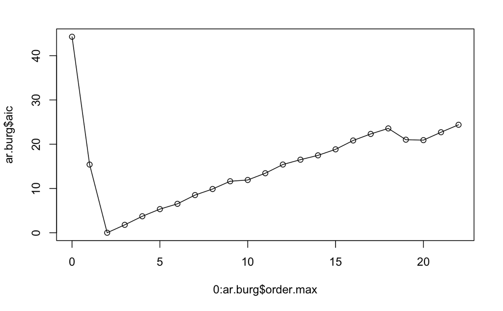

```r
ar.burg <- ar(residuals(olm.fit), method = "burg")
plot(0:ar.burg$order.max, ar.burg$aic, type='o')
```

It seems that $p=2$ is a good option, since this one shows a substantially kink in the line.

## c)

Estimate the regression coefficients and the AR parameters using Generalized Least Squares with Maximum Likelihood estimation. To ensure convergence of the algorithm, known estimates of the AR parameters can be passed to corARMA() as starting values using the optional argument values. In this particular case, this does not change the outcome.(correlation = corARMA(…, value = r.burg$ar, …))

```r
summary(r.bel.gls)
```

```
Generalized least squares fit by maximum likelihood
  Model: NURSING ~ .
  Data: d.beluga
```

|  | AIC | BIC | logLik |
| --- | --- | --- | --- |
|  | 560.396 | 584.9974 | -272.198 |

```
Correlation Structure: ARMA(2,0)
 Formula: ~PERIOD
 Parameter estimate(s):
     Phi1      Phi2
0.2739974 0.3653663

Coefficients:
```

|  | Value | Std.Error | t-value | p-value |
| --- | --- | --- | --- | --- |
| (Intercept) | 1.3218875 | 0.7678369 | 1.721573 | 0.0871 |
| PERIOD | 0.0024982 | 0.0062754 | 0.398089 | 0.6911 |
| BOUTS | 0.2961689 | 0.3370588 | 0.878686 | 0.3809 |
| LOCKONS | 2.5681918 | 0.1964012 | 13.076253 | 0.0000 |
| DAYNIGHT | -0.3080292 | 0.1549160 | -1.988362 | 0.0485 |

```
 Correlation:
         (Intr) PERIOD BOUTS  LOCKON
PERIOD   -0.607
BOUTS    -0.303 -0.233
LOCKONS  -0.101  0.251 -0.811
DAYNIGHT -0.014  0.024 -0.135  0.067

Standardized residuals:
        Min          Q1         Med          Q3         Max
-2.80055479 -0.58763711  0.01738819  0.65602026  2.49854049

Residual standard error: 1.577032
Degrees of freedom: 160 total; 155 residual
```

From the output of gls, we can infer the $\alpha_1$ parameter to be $0.274$ and the $\alpha_2$ parameter to be $0.365$.

# Exercise 8.3

With the new material in the course we would like to return to Exercise 7.3.

```r
t.url <- "http://stat.ethz.ch/Teaching/Datasets/WBL/varve.dat"
d.varve <- ts(scan(t.url)[201:550])
```

```
Read 634 items
```

## a)

Choose a suitable model that fits the data. Does your model fit? Analyze the residuals and comment on your decision.

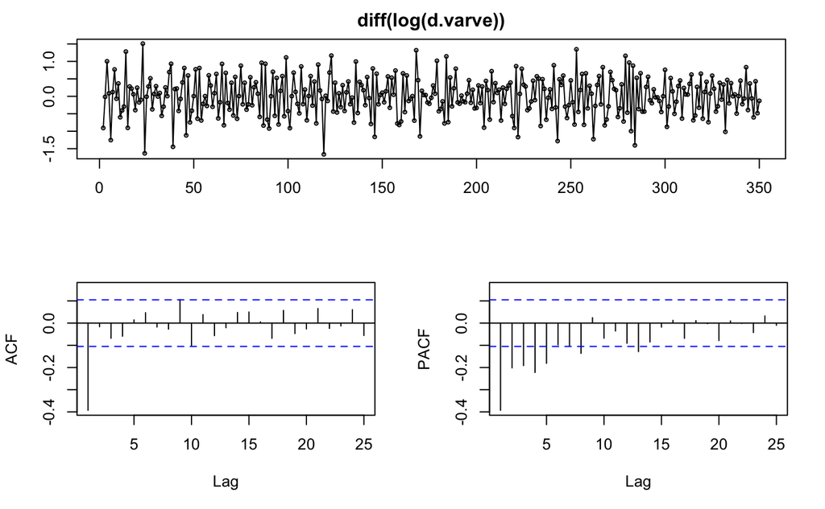

Looking at the (P)ACF plots, I would model this dataset as an $ARIMA(1,1,1)$ process ($I=1$ because we applied $diff$ once).

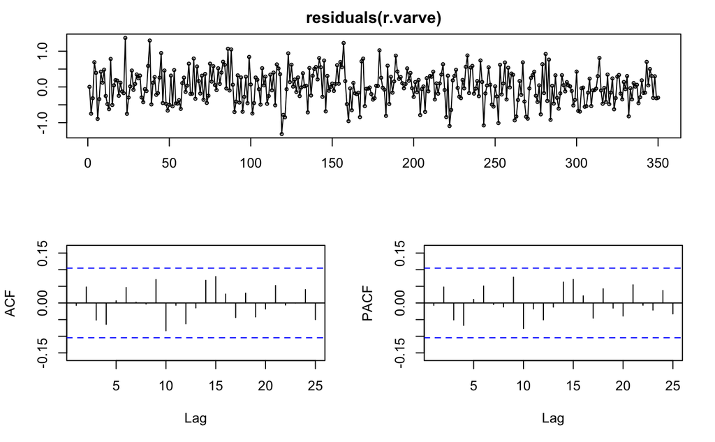

```r
r.varve <- arima(log(d.varve), order = c(1, 1, 1))
tsdisplay(residuals(r.varve))
```

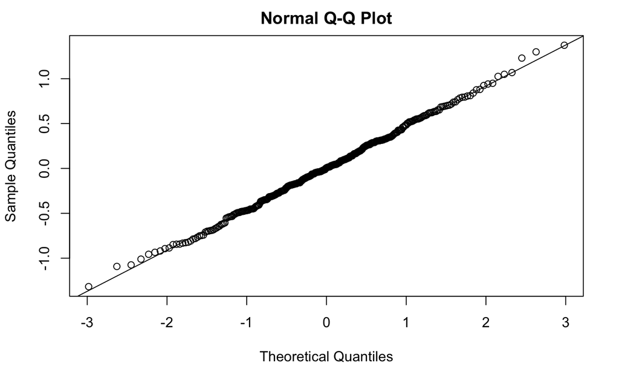

```r
qqnorm(residuals(r.varve))
qqline(residuals(r.varve))
```

This looks really good, since no structure is present anymore in the residuals. We can also see from the QQ-Plot, that all points follow the line really closely, so no real outliers detected there.

## b)

Write down the model you chose in a) with its estimated coefficients.

```r
r.varve$coef
```

```
       ar1        ma1
 0.2460979 -0.9139682
```

```r
r.varve$sigma2
```

```
[1] 0.2137604
```

The model looks as follows:

$$Y_t = 0.25 * Y_{t-1} + E_t - 0.91 * E_{t-1}$$
with
$$\sigma^2_{E_t} = 0.214$$